# Lecture-Lab 3: Survey data collection and analysis

KNHSM08 / KOMP014: Quantitative Methods in  
Music Education Research 2026

nils.holmberg@iko.lu.se

## Lecture-Lab 1

- **Module:** Survey data
- **Topic:** Research design, theoretical models, survey construction, data collection, descriptive analysis
- **Date:** 2026-09-01 at 11—17
- **Place:** MHM
- **Readings:** Muijs (2011), chs. 1 and 3–4; Ehninger et al. (2021)

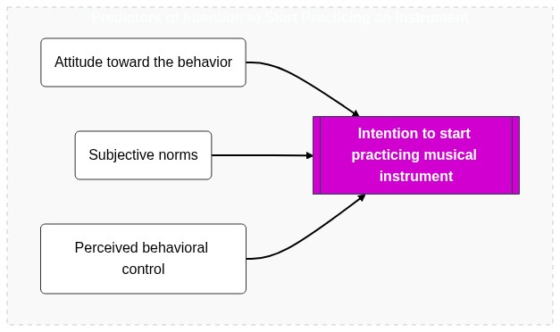

## Lecture-Lab 2 (David Johnson)

- **Module:** Survey data
- **Topic:** Data collection, data analysis, descriptive, univariate, bivariate, frequencies, distributions
- **Date:** 2026-09-04 at 09—12
- **Place:** Zoom
- **Readings:** Muijs (2011), chs. 5–6; Johnson (2021), chs. 1, 4–5

[figure not shown]

## Lecture-Lab 3

- **Module:** Survey data
- **Topic:** Online survey experiments, inferential analysis, hypothesis testing, [Jamovi](https://www.jamovi.org/download.html) software
- **Date:** 2026-09-08 at 11—17
- **Place:** MHM
- **Readings:** Muijs (2011), chs. 2, 7–8; Krupp-Schleußner and Lehmann-Wermser (2018)

[figure not shown]

## Lecture-Lab 4 (Gary McPherson)

- **Module:** Survey data
- **Topic:** Multivariate analysis, association, correlation, causality, survey data collection and analysis
- **Date:** 2026-09-11 at 09—12
- **Place:** Zoom
- **Readings:** Muijs (2011), chs. 7–10; McPherson and O’Neill (2010b); McPherson and O’Neill (2010a)

[figure not shown]

## Lecture-Lab 5

- **Module:** Extended data
- **Topic:** Attitudes vs. content, quantitative content analysis, natural language processing (NLP), process tracing
- **Date:** 2026-09-15 at 11—17
- **Place:** MHM
- **Readings:** Ehninger et al. (2021); Johnson (2021), ch. 4

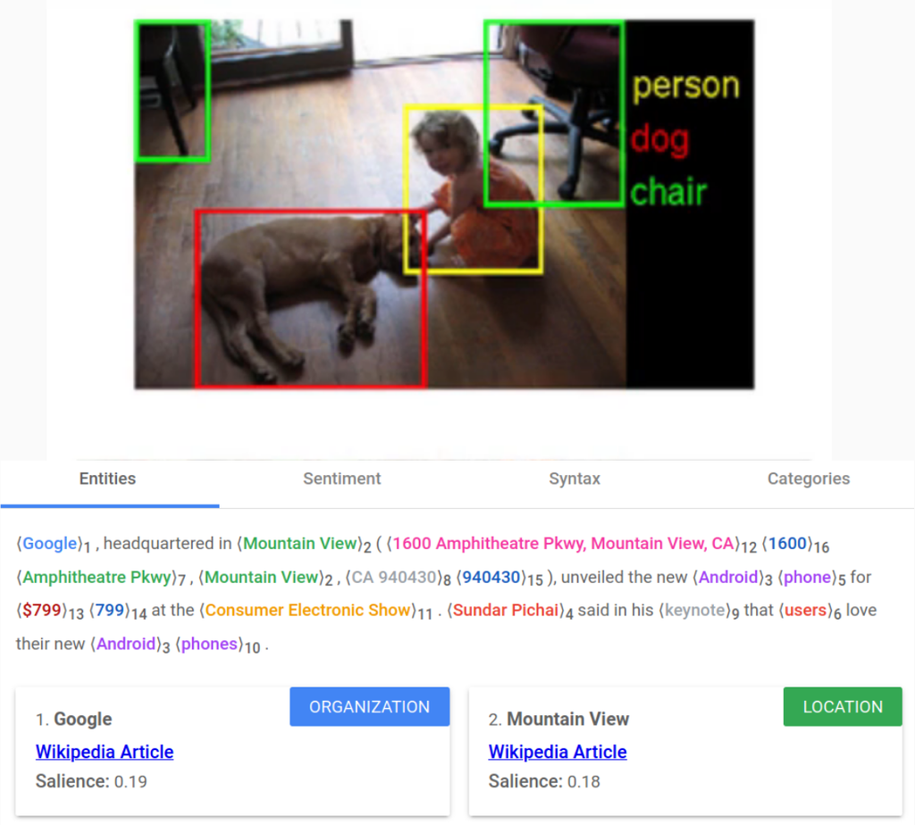

## Individual Work 1

- **Module:** Survey data
- **Topic:** Design and implement a quantitative study (questionnaire or content) using [Google Forms](https://docs.google.com/forms/?authuser=0)
- **Date:** 2026-09-18 at 09—12
- **Place:** Zoom
- **Readings:**

📚 💻  
🧑‍🎓

## Lecture-Lab 6

- **Module:** Extended data
- **Topic:** Multivariate analysis and multiple linear regression (MLR) analysis, using [Google Colab](https://colab.research.google.com/)
- **Date:** 2026-09-22 at 11—17
- **Place:** Zoom or MHM
- **Readings:** Muijs (2011), ch. 9; Djurfeldt and Barmark (2009), chs. 3, 5–6; Björk et al. (2019)

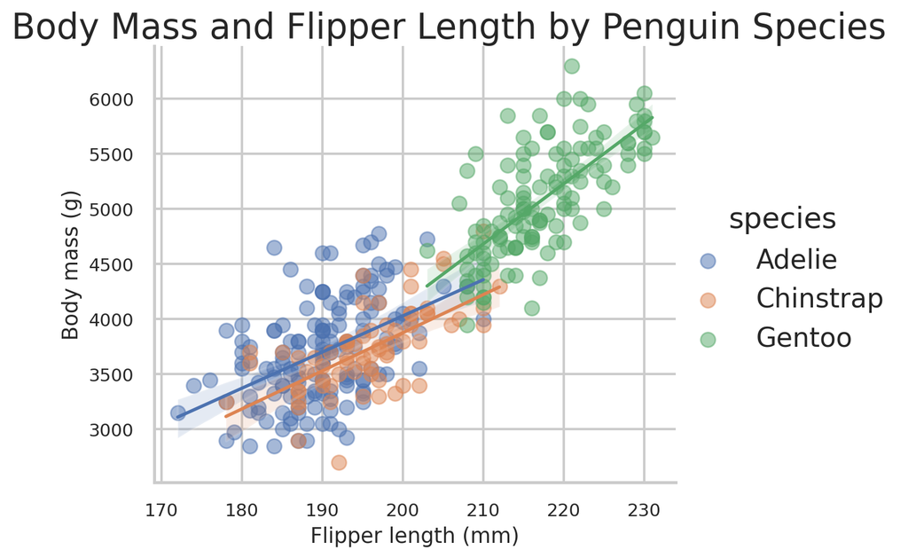

## Lecture-Lab 7

- **Module:** Extended data
- **Topic:** Interactions between variables, data transformations, logistic regression, using [Google Colab](https://colab.research.google.com/)
- **Date:** 2026-09-25 at 09—12
- **Place:** Zoom
- **Readings:** Muijs (2011), ch. 12; Djurfeldt and Barmark (2009), ch. 10

[figure not shown]

## The IMRD structure

Intro

Methods

Results

Discussion

## The Theoretical Model

- **Hypothesis**: A tentative, testable explanation accepted or rejected provisionally.
- **Attitude**: A student’s evaluation of practising their instrument.
- **Subjective Norm**: Perceived pressure from parents, teachers, and peers.
- **Perceived Control**: Perceived ease or difficulty of practising.
- **Formulated Hypothesis**: Attitudes, norms, and control predict practice intentions.

Intro

Methods

Results

Discussion

## Theory of Planned Behavior

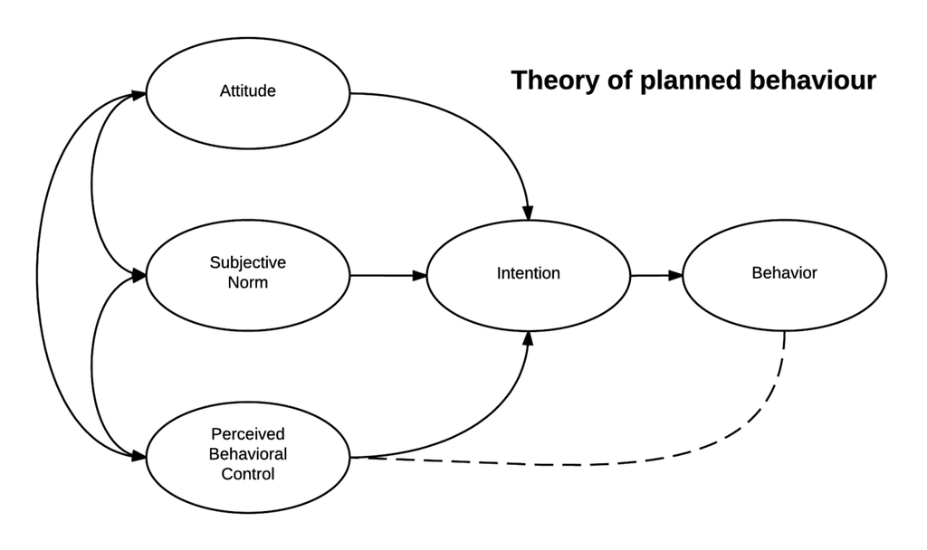

- https://en.wikipedia.org/wiki/Theory_of_planned_behavior

## Applied TPB

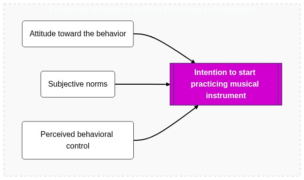

## Lab 1.1: Theoretical model

- `Theoretical foundation`
- Operationalization of variables
- Measurement design and questionnaire construction
- Population and sampling strategy
- Data quality and fieldwork procedures

```
graph LR
    direction LR

    subgraph Analysis [<b>Predictors of Intention to Start Practicing an Instrument</b>]
        direction LR

        %% Independent Variables (TPB Constructs)
        iv1(Attitude toward the behavior)
        iv2(Subjective norms)
        iv3(Perceived behavioral control)

        %% Dependent Variable
        dv1[[<b>Intention to start practicing</b>]]

        %% Connections
        iv1 --> dv1
        iv2 --> dv1
        iv3 --> dv1
    end

    %% Node Styling
    style Analysis fill:#f9f9f9,stroke:#ccc,stroke-dasharray: 5 5
    style iv1 fill:#ffffff,stroke:#333,color:#000
    style iv2 fill:#ffffff,stroke:#333,color:#000
    style iv3 fill:#ffffff,stroke:#333,color:#000
    style dv1 fill:#d100d1,stroke:#2b4156,color:#fff

    %% Darker Arrow Styling (Indices start at 0)
    linkStyle 0,1,2 stroke:#000,stroke-width:2px;
```

## Lecture-Lab 3.1: Survey construction and data collection

KNHSM08 / KOMP014: Quantitative Methods in  
Music Education Research 2026

nils.holmberg@iko.lu.se

## Ethical TPB Surveys & Informed Consent

- **Informed Consent**: Obtain parental and student consent before surveying school musicians.
- **Anonymity Guarantee**: Protect anonymity to encourage honest reports of practice habits.
- **Voluntary Participation**: Students may decline or withdraw without penalty.
- **Clear Research Purpose**: Explain the study and how responses will be used.
- **Establishing Credibility**: Institutional credibility helps improve student response rates.

Intro

Methods

Results

Discussion

## Survey Structure for Musical Practice

- **Thematic Blocks**: Organize questions into clear, logical sections.
- **Outcome Section**: Begin with intention to practise, the dependent variable.
- **Theoretical Predictors**: Separate attitudes, subjective norms, and perceived control.
- **Covariates Section**: Group lesson history, instrument family, and grade level.
- **Demographics at the End**: Put sensitive questions last to reduce attrition.

Intro

Methods

Results

Discussion

## Survey Items for Young Musicians

- **Clear and Simple Phrasing**: Match wording to students’ reading levels.
- **Avoid Double Negatives**: Remove negative phrasing that increases cognitive burden.
- **One Question Per Item**: Split statements that ask about two things.
- **Minimize Jargon**: Avoid technical, institutional, or culturally insensitive terms.
- **Instrument Piloting**: Test drafts with teachers and a small student sample.

Intro

Methods

Results

Discussion

## Latent Constructs: Dimensions & Indicators

- **Latent Variables**: TPB concepts cannot be observed directly.
- **Multidimensional Constructs**: Complex concepts may contain several dimensions.
- **Manifest Indicators**: Measure each dimension with survey items.
- **Error Cancellation**: Multiple indicators reduce individual response error.
- **Optimal Scale Length**: Use 4–10 items, balancing reliability and burden.

Intro

Methods

Results

Discussion

## Dimensions & Indicators

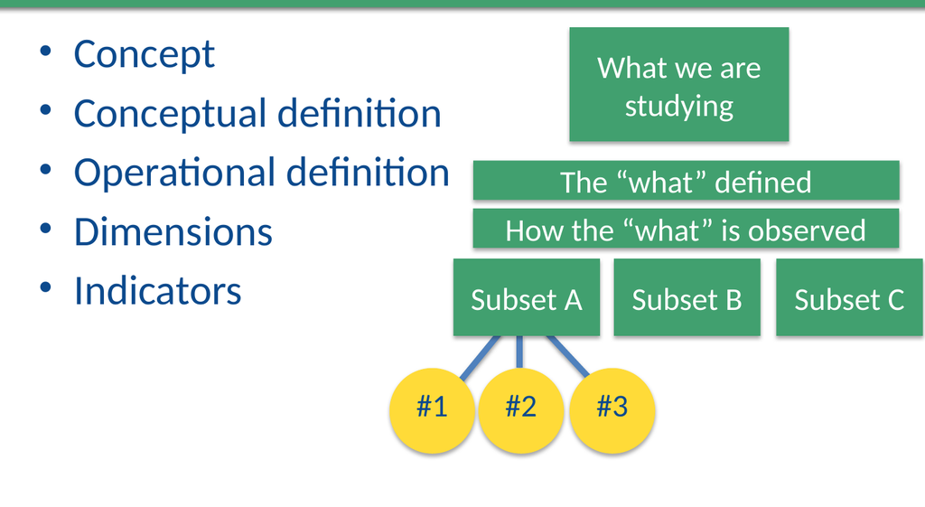

## Response Formats & Alternatives

- **Open-Ended Limitations**: Rich responses are time-consuming to code.
- **Closed-Ended Comparability**: Predefined choices enable straightforward statistical comparison.
- **Likert Scale Formats**: Rate agreement from strongly disagree to strongly agree.
- **Don’t Know Category**: Avoid forcing uninformed students toward neutral responses.

Intro

Methods

Results

Discussion

## Response Biases in Music Research

- **Social Desirability Bias**: Students may exaggerate practice to please adults.
- **The Hawthorne Effect**: Being studied may temporarily change practice habits.
- **Positive Response Bias**: High ratings can obscure genuine practice priorities.
- **Central Tendency Problem**: Students may avoid commitment by choosing midpoints.
- **Evaluator Bias**: A researcher’s presence can systematically influence answers.

Intro

Methods

Results

Discussion

## Sampling Strategies & Sample Bias

- **Target Population**: The music students to whom findings should generalise.
- **Unbiased Representation**: Representative samples support population-level conclusions.
- **Simple Random Sampling**: Give every student an equal selection chance.
- **Stratified & Quota Sampling**: Ensure rare subgroups are represented.
- **Cluster & Multistage Sampling**: Select schools, then nested classrooms or students.

Intro

Methods

Results

Discussion

## Online, Paper, and Telephone Surveys

- **Pencil-and-Paper Surveys**: Familiar and self-paced, but require manual entry.
- **Online Survey Efficiency**: Direct database capture prevents transcription errors.
- **Access Gaps**: Unequal internet access can bias online samples.
- **Telephone Surveys**: Help fill quotas but often face non-response.
- **Maximizing Response Rates**: Use short surveys, incentives, and timely reminders.

Intro

Methods

Results

Discussion

## Data Screening & Missing Values in SPSS

- **Source of Missingness**: Skipped items, invalid codes, and dropout create missing data.
- **Loss of Power**: Missing responses reduce sample size and statistical power.
- **SPSS Output Interpretation**: “Valid Percent” excludes missing cases.
- **Dedicated Missing Codes**: Assign distinct codes such as 99 or 999.

Intro

Methods

Results

Discussion

## Index Variables & Recoding TPB Scales

- **Recoding Variables**: Reverse negative items so all scores align.
- **Creating Index Variables**: Sum or average items into continuous TPB scales.
- **Data Transformations**: Convert practice hours into categories using cutoffs.
- **Dummy Variables**: Recode nominal predictors into binary indicators.
- **Internal Consistency**: Check Cronbach’s alpha before calculating scale indexes.

Intro

Methods

Results

Discussion

Lab 3.1:  
Survey construction and data collection

## Lab 3.1: Theoretical model

- Theoretical foundation
- Operationalization of variables
- `Measurement design and questionnaire construction`
- Population and sampling strategy
- Data quality and fieldwork procedures

```
graph LR
    direction LR

    subgraph Analysis [<b>Predictors of Intention to Start Practicing an Instrument</b>]
        direction LR

        %% Independent Variables (TPB Constructs)
        iv1(Attitude toward the behavior)
        iv2(Subjective norms)
        iv3(Perceived behavioral control)

        %% Dependent Variable
        dv1[[<b>Intention to start practicing</b>]]

        %% Connections
        iv1 --> dv1
        iv2 --> dv1
        iv3 --> dv1
    end

    %% Node Styling
    style Analysis fill:#f9f9f9,stroke:#ccc,stroke-dasharray: 5 5
    style iv1 fill:#ffffff,stroke:#333,color:#000
    style iv2 fill:#ffffff,stroke:#333,color:#000
    style iv3 fill:#ffffff,stroke:#333,color:#000
    style dv1 fill:#d100d1,stroke:#2b4156,color:#fff

    %% Darker Arrow Styling (Indices start at 0)
    linkStyle 0,1,2 stroke:#000,stroke-width:2px;
```

## Lab 3.1: Data collection plan

| Dimension | Description |
| --- | --- |
| 1. Theoretical foundation | Research question, theoretical framework, and hypotheses that guide what must be measured. |
| 2. Operationalization of variables | Translation of concepts into measurable variables; use of validated scales and multi-item constructs where appropriate. |
| 3. Population and sampling strategy | Definition of target population, sampling frame, recruitment method, and planned sample size. |
| 4. Measurement design and questionnaire construction | Question wording, response formats, survey structure, pilot testing, and flow logic. |
| 5. Data quality and fieldwork procedures | Attention checks, prevention of duplicate responses, ethical procedures, and administration mode. |

## Lab 3.1: Quantitative proposal

```python
# Using RQ below, develop point 1-5 to generate a data collection plan, including suggestions for survey questions and response alternatives using validated scales with literature references!
# RQ:

# 1. Theoretical foundation
# Answer:

# 2. Operationalization of variables
# Answer:

# 3. Population and sampling strategy
# Answer:

# 4. Measurement design and questionnaire construction
# Answer:

# 5. Data quality and fieldwork procedures
# Answer:
```

- https://share.gemini.google/DNTjVxw6TpC0
- Enter survey items into [Google Forms](https://docs.google.com/forms/?authuser=0)

## Lecture-Lab 3.2: Online survey experiments and causality

KNHSM08 / KOMP014: Quantitative Methods in  
Music Education Research 2026

nils.holmberg@iko.lu.se

## Between-Subjects Design

- **Independent Groups**: Each child receives only one version—A or B—so responses come from different participants.
- **Random Assignment**: Give every child an equal chance of entering either group to reduce allocation bias.
- **A/B Contrast**: A is the control experience; B changes only the peer-testimonial element.
- **Hypotheses**: $H_0$ predicts equal mean intention; $H_1$ predicts higher intention after the testimonial.

Intro

Methods

Results

Discussion

## TPB + Peer Testimonial Treatment

- **Research Question**: Does reading a positive child peer testimonial increase intention to begin practising a musical instrument?
- **Survey Flow**: Demographics + ATT/SN/PBC → randomize → vignette → three BI outcome items.
- **Control (A)**: No peer testimonial; operationally, use a length-matched neutral screen to hold attention constant.
- **Treatment (B)**: A relatable child describes starting an instrument, enjoying progress, and intending to continue.

Intro

Methods

Results

Discussion

## 2×2 Factorial: Two Manipulations at Once

- **Factorial Logic**: Cross two manipulated factors, each with two levels, to create four experimental cells.
- **Factor A**: Child peer testimonial absent versus present.
- **Factor B**: Concrete action-planning prompt absent versus present.
- **Three Questions**: Estimate the testimonial main effect, planning main effect, and testimonial × planning interaction.

Intro

Methods

Results

Discussion

## Factorial Example: Four Survey Conditions

- **Cell 1—Neither**: Neutral screen; no testimonial and no planning prompt.
- **Cell 2—Testimonial Only**: Peer story appears, followed directly by the BI questions.
- **Cell 3—Planning Only**: No story; child chooses when, where, and how to start practising.
- **Cell 4—Both**: Peer story plus the action-planning prompt; hypothesize the largest BI mean here.

Intro

Methods

Results

Discussion

## Repeated Measures Design

- **Within-Subjects Logic**: Every child completes both control and testimonial conditions at different times, two BI indices per child.
- **Built-In Control**: Stable characteristics—age, enthusiasm, prior confidence—are held constant within the child.
- **Greater Precision**: Analyze within-child change, often with more power than an equally sized independent-groups design.

Intro

Methods

Results

Discussion

## Within-Subjects Example

- **Two Scenarios**: Each child considers two matched unfamiliar instruments; one scenario is control and one contains the testimonial.
- **Counterbalancing**: Randomize condition order and which instrument receives the testimonial across four sequences.
- **Sequence**: Scenario 1 → BI-1 → filler task → Scenario 2 → BI-2; keep wording and timing equivalent.

Intro

Methods

Results

Discussion

## TPB Vignette as Quasi-Experiment

- **Non-Random Exposure**: A school or teacher chooses who receives the peer testimonial; children no longer have equal assignment probabilities.
- **Comparison Group**: Children without the testimonial become a comparison group—not a pure randomized control group.
- **Make Groups Comparable**: Match or adjust for age, grade, gender, ATT, SN, and PBC measured before the vignette.

Intro

Methods

Results

Discussion

## JeKi: Non-Randomized Comparison

- **Programme Exposure**: JeKi offered group instrumental lessons during primary school; researchers did not randomly assign participation.
- **Longitudinal Sample**: 886 pupils were surveyed twice; analyses used 529 who responded at both waves; musical participation was measured later in Grades 6 and 7.
- **Comparison**: 40.1% had participated in JeKi, allowing comparison with pupils who had not received the programme.

Intro

Methods

Results

Discussion

## JeKi: Effect of Participation

- **Continuation**: 58.1% of former JeKi pupils learned the same instrument (24.8%) or another instrument (33.3%) after primary school.
- **Special Music Classes**: Former JeKi pupils were not significantly more likely than non-participants to attend them.
- **Stronger Predictors**: Musical affinity (OR = 1.54/2.11) and music at home (OR = 1.94/1.73) predicted lessons in Grades 6/7.

Intro

Methods

Results

Discussion

## JeKi: Logistic Regression, Odds Ratios

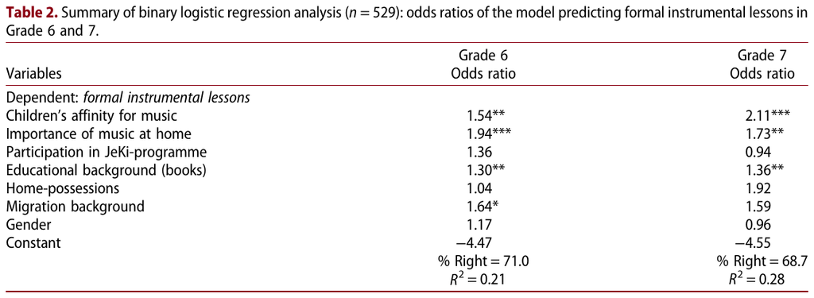

- **OR = 1**: no difference in odds; **OR > 1**: higher odds; **OR < 1**: lower odds.
- Convert an OR above 1 with $(OR-1)\times100\%$. An OR of 1.54 means **54% higher odds**, not a 54-point increase in probability.
- **Affinity**: each one-unit increase was associated with 54% higher odds in Grade 6 and 111% higher odds in Grade 7 (OR = 1.54 and 2.11).
- **JeKi**: OR = 1.36 in Grade 6 and 0.94 in Grade 7, but neither estimate was significant. The data therefore do not establish higher or lower odds due to JeKi.
- Stars indicate estimates the authors judged statistically distinguishable from OR = 1; uncertainty must accompany the size of an OR.

## JeKi: Adjusted Associations

- **Explained Variation**: The Grade 7 linear model explained 36% of variance in musical involvement.
- **Key Associations**: Musical affinity ($\beta=.40$) and music at home ($\beta=.21$) were significant positive predictors.
- **Quasi-Experimental Lesson**: Statistical controls reduce known differences, but selection, attrition, and unmeasured confounding still limit causal claims.

Intro

Methods

Results

Discussion

## JeKi: Linear Model, Adjusted Results

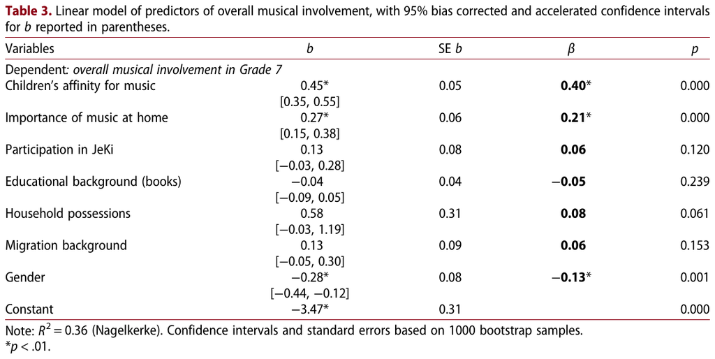

- **Standardized $\beta$** expresses an adjusted association on a common scale: larger absolute values indicate stronger relationships, holding the other predictors constant.
- **Affinity** was the strongest positive predictor ($\beta=.40$, $p<.001$), followed by **music at home** ($\beta=.21$, $p<.001$).
- **JeKi participation** was weak and non-significant after adjustment ($\beta=.06$, $p=.120$; 95% CI for $b$: $-.03$ to $.28$).
- The model reported $R^2=.36$: the included predictors collectively accounted for about 36% of variation in overall musical involvement.
- Adjustment addresses measured differences only; in this non-randomized study, the coefficients remain **associations rather than causal effects**.

Lab 3.2:  
Online survey experiments and causality

## Lab 3.2: Quantitative proposal

```python
# Using experiment design below, develop point 1-2 to generate short single paragraph text vignette stimuli using validated formulations with literature references!
# Experiment design: TPB survey with treatment condition in the form of a child peer testimonial text vingnette telling participants about how they started practicing a musical instrument and how they benefited from this in other academic areas. Control condition is a comparable neutral text about music education.

# 1. Control condition
# Answer:

# 2. Treatment condition
# Answer:
```

- https://share.gemini.google/DNTjVxw6TpC0
- Enter experimental conditions into [Google Forms](https://docs.google.com/forms/?authuser=0)

## Lab 3.2: Workshop instructions

- test [demo](https://jolly-crumble-aa07a6.netlify.app/) survey experiment
- create free account at [netlify](https://app.netlify.com/)
- copy [google](https://drive.google.com/drive/folders/1oBtJoq4Gl3VBkN1azBRdYJuGOmHhJ5ps) experiment materials
- get random assignment app on [github](https://github.com/nils-holmberg/scom-expm/tree/main/web/forms)
- recap [youtube](https://www.youtube.com/watch?v=RpEeZiV8jGY) instruction video

## Lecture-Lab 3.3: Descriptive and inferential data analysis

KNHSM08 / KOMP014: Quantitative Methods in  
Music Education Research 2026

nils.holmberg@iko.lu.se

## Descriptive Results & Univariate Analysis

- **Univariate Focus**: Examine each variable before studying relationships.
- **Data Screening**: Detect entry errors, invalid values, and missing data.
- **Level Constraints**: Measurement level determines appropriate descriptive statistics.
- **Variables Checklist**: Summarize backgrounds, TPB predictors, and practice intentions.
- **Initial Study Screen**: Count completed surveys and missing responses.

Intro

Methods

Results

Discussion

## Demographics & Frequency Analysis

- **Frequency Distribution**: Lists observed values and how often they occur.
- **Reporting Categorical Data**: Describe categories with counts and percentages.
- **SPSS Frequency Tables**: Use “Valid Percent” to exclude missing cases.
- **Cumulative Percent**: Shows the proportion at or below each ordered category.
- **Instrument Breakdown**: Report shares of strings, brass, woodwind, and percussion.

Intro

Methods

Results

Discussion

## Visualizing Categories: The Bar Plot

- **Categorical Visualization**: Use bar plots for nominal and ordinal frequencies.
- **Categorical X-Axis**: Displays categories or rating options.
- **Frequency Y-Axis**: Displays counts or percentages in each category.
- **Distribution Inspection**: Bar heights reveal dominant responses and skew.
- **Fun of Practice Item**: Plot one item to inspect agreement patterns.

Intro

Methods

Results

Discussion

## Demographics and Assignment

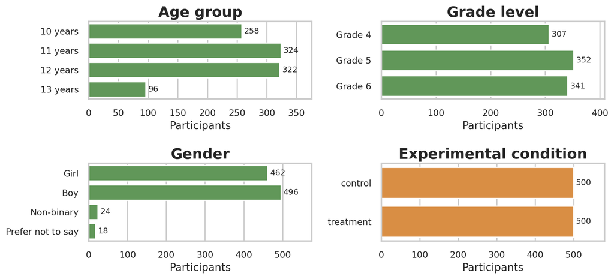

## Continuous Scale Variables & Distributions

- **Continuous Latent Scales**: Treat standardized scores and index averages as continuous.
- **Distribution Shape**: Inspect how scores spread across their possible range.
- **The Bell Curve**: Normal distributions are symmetric around the center.
- **Positive and Negative Skew**: Scores cluster toward one end of the scale.
- **Practice Hours Distribution**: Check whether most students report few hours.

Intro

Methods

Results

Discussion

## TPB Index Distributions

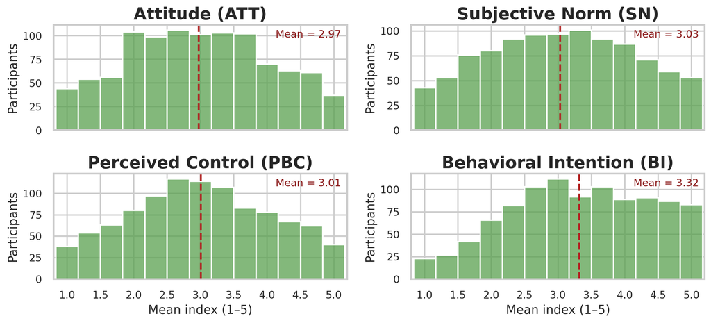

## Measures of Central Tendency

- **Summarizing Distributions**: Represent a variable with one typical score.
- **The Mode**: Most frequent value; suitable for nominal variables.
- **The Median**: Middle ranked score; suitable for ordinal data.
- **The Mean**: Sum of scores divided by the number of cases.
- **Outlier Sensitivity**: Prefer the median when extremes distort the mean.

Intro

Methods

Results

Discussion

## Measures of Spread and Dispersion

- **Concept of Spread**: Describes variation around the central value.
- **The Range**: Highest minus lowest score; sensitive to outliers.
- **Interquartile Range (IQR)**: Spread of the middle 50% of scores.
- **Standard Deviation (SD)**: Typical distance of scores from the mean.
- **SD Normal Rule**: About 68% lie within one SD of the mean.

Intro

Methods

Results

Discussion

## Descriptive Bivariates: Group Averages

- **Bivariate Comparison**: Compare groups on a continuous outcome.
- **Gender Skew Check**: Cross-tabulate gender across instrument sections.
- **SPSS Case Selection**: Select subgroups and calculate separate statistics.
- **Mean Comparison Table**: Compare average intentions between groups.
- **Subgroup Differences**: Identify instrument families with higher practice averages.

Intro

Methods

Results

Discussion

## Visualizing Group Differences: The Box Plot

- **Box Plot Utility**: Compare center and spread across groups.
- **The Median Line**: Marks each group’s 50th percentile.
- **The Box Dimensions**: Show the middle 50% of scores.
- **Whiskers**: Mark the range of typical, non-extreme values.
- **Outlier Identification**: Separate points flag unusually high or low cases.

Intro

Methods

Results

Discussion

## Intention by Experimental Condition

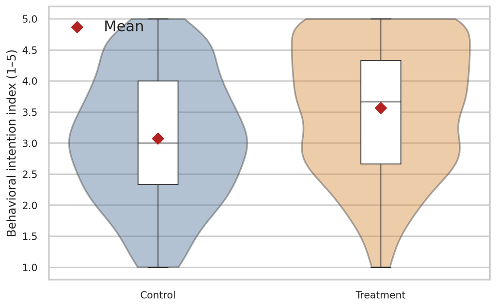

## Continuous Predictors and Outcome

- **Continuous Bivariate**: Examine two continuous variables together.
- **Positive Association**: Higher attitudes accompany stronger practice intentions.
- **Negative Association**: Greater barriers accompany weaker practice intentions.
- **Linear Relationships**: Predictor changes correspond to constant outcome changes.
- **Curvilinear Relationships**: Effects change strength or direction across values.

Intro

Methods

Results

Discussion

## Visualizing Scale Data: The Scatter Plot

- **Scatter Plot Design**: Plot each student as an X–Y point.
- **Horizontal X-Axis**: Displays the continuous predictor, such as Attitude.
- **Vertical Y-Axis**: Displays the continuous outcome, such as Intention.
- **Visualizing Density**: Clustering and slope show direction and strength.
- **Spotting Anomalies**: Isolated points reveal students outside the general trend.

Intro

Methods

Results

Discussion

## TPB Predictors and Intention

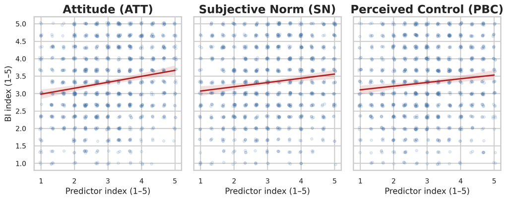

## Cross-Tabs and Chi-Square

- **Categorical Pair**: Cross-tabulate two variables measured as categories.
- **Observed and Expected**: Compare cell counts with values expected under independence.
- **Null Hypothesis**: Condition and each demographic variable are unrelated.
- **Chi-Square Test**: A small p-value challenges independence; inspect the cells.
- **Effect Size**: Cramér’s V summarizes strength apart from sample size.

Intro

Methods

Results

Discussion

## Randomization Balance Check

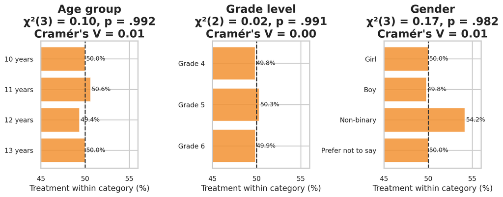

## Independent-Samples *t*-Test

- **Measurement Match**: Compare a continuous outcome across two independent groups.
- **Null Hypothesis**: Control and treatment have the same population mean BI.
- **Welch Test**: Tests the mean difference without assuming equal population variances.
- **Statistical Uncertainty**: Report *t*, df, p, and a confidence interval.
- **Practical Magnitude**: Cohen’s *d* expresses the difference in pooled SD units.

Intro

Methods

Results

Discussion

## Treatment Increased Behavioral Intention

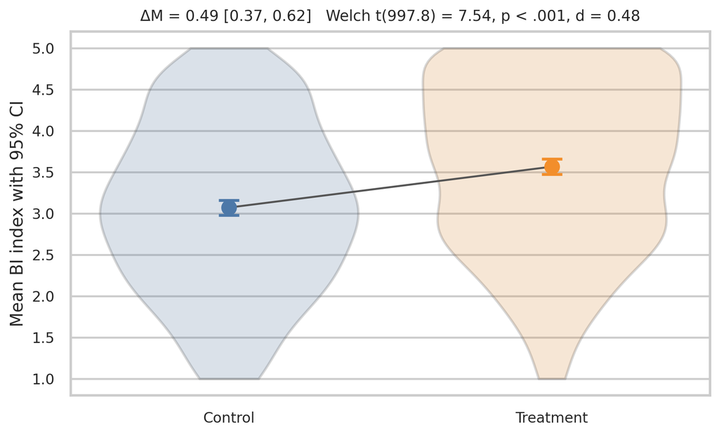

## Pearson Correlation

- **Measurement Match**: Use Pearson’s *r* for two continuous variables linked linearly.
- **Direction**: Positive values rise together; negative values move oppositely.
- **Strength**: Values run from −1 to +1; distance from zero indicates association.
- **Inference**: Report *r*, sample size, p, and preferably a confidence interval.
- **Interpret Carefully**: Squared *r* summarizes shared variation, not causation.

Intro

Methods

Results

Discussion

## TPB Predictors, Positive Associations

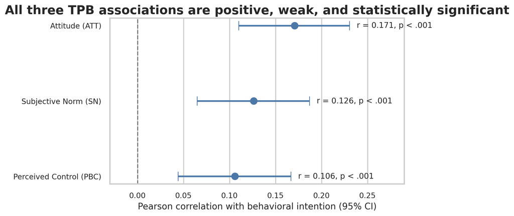

Lab 3.3:  
Descriptive and inferential data analysis

## Lab 3.3: Theoretical model

- Download synthetic [dataset](https://github.com/cca-cce/osm-comm/tree/main/csv/edu/komp014) and begin to analyze model
- `Perform descriptive statistics`
- Perform bivariate analyses and hypothesis testing
- Perform multivariate analysis, multiple regression

```
graph LR
    direction LR

    subgraph Analysis [<b>Predictors of Intention to Start Practicing an Instrument</b>]
        direction LR

        %% Independent Variables (TPB Constructs)
        iv1(Attitude toward the behavior)
        iv2(Subjective norms)
        iv3(Perceived behavioral control)

        %% Dependent Variable
        dv1[[<b>Intention to start practicing</b>]]

        %% Connections
        iv1 --> dv1
        iv2 --> dv1
        iv3 --> dv1
    end

    %% Node Styling
    style Analysis fill:#f9f9f9,stroke:#ccc,stroke-dasharray: 5 5
    style iv1 fill:#ffffff,stroke:#333,color:#000
    style iv2 fill:#ffffff,stroke:#333,color:#000
    style iv3 fill:#ffffff,stroke:#333,color:#000
    style dv1 fill:#d100d1,stroke:#2b4156,color:#fff

    %% Darker Arrow Styling (Indices start at 0)
    linkStyle 0,1,2 stroke:#000,stroke-width:2px;
```

## Lab 3.3: Data analysis plan

| Dimension | Description |
| --- | --- |
| 1. Analytical strategy | Specification of research aims and overall statistical approach aligned with hypotheses. |
| 2. Descriptive statistics | Summary of distributions, central tendencies, dispersion, and visualization of key variables. |
| 3. Data transformations | Index construction, reverse coding, scale reliability checks, recoding, and preparation for analysis. |
| 4. Bivariate analysis and hypothesis testing | Correlation analysis, mean comparisons, cross-tabulations, and initial hypothesis tests. |
| 5. Multivariate analysis and diagnosis | Regression or advanced modeling, inclusion of control variables, assumption checks, and model diagnostics. |

## Lab 3.3: Quantitative proposal

```python
# Using RQ below, develop point 1-5 to generate a data analysis plan!
# RQ:

# 1. Analytical strategy
# Answer:

# 2. Descriptive statistics
# Answer:

# 3. Data transformations, e.g. index variables
# Answer:

# 4. Bivariate analysis and hypothesis testing
# Answer:

# 5. Multivariate analysis and diagnosis
# Answer:
```

- https://share.gemini.google/DNTjVxw6TpC0

## References

Björk, Cecilia, Marja-Leena Juntunen, Jens Knigge, Bernd Pape, and Lars-Erik Malmberg. 2019. “Musikundervisning Förverkligas På Ojämlika Villkor i Årskurserna 1–6 i Finlands Svenskspråkiga Skolor.” *Finnish Journal of Music Education* 22: 30–58.

Djurfeldt, Göran, and Mimmi Barmark. 2009. *Statistisk Verktygslåda 2: Multivariat Analys*. Studentlitteratur. https://minprodukt2.studentlitteratur.se/dill/#/tematoc/33163_statistisk_verktygslada_2.

Ehninger, Julia, Jens Knigge, Michael Schurig, and Christian Rolle. 2021. “A New Measurement Instrument for Music-Related Argumentative Competence: The MARKO Competency Test and Competency Model.” *Frontiers in Education* 6: 668538. https://doi.org/10.3389/feduc.2021.668538.

Johnson, David. 2021. “Raising Voices: Singing Repertoire and Practices in Swedish Schools.” PhD thesis, Lund University. https://lucris.lub.lu.se/ws/portalfiles/portal/96905350/Raising_Voices.pdf.

Krupp-Schleußner, Valerie, and Andreas Lehmann-Wermser. 2018. “An Instrument for Every Child: A Study on Long-Term Effects of Extended Music Education in German Primary Schools.” *Music Education Research* 20 (1): 44–58. https://doi.org/10.1080/14613808.2016.1249361.

McPherson, Gary E., and Susan A. O’Neill. 2010a. *Student Questionnaire: Motivation to Study Music Compared to Other School Subjects*. Survey instrument, 38 items, 10 pp. https://doi.org/10.1177/1321103X10384202.

McPherson, Gary E., and Susan A. O’Neill. 2010b. “Students’ Motivation to Study Music as Compared to Other School Subjects: A Comparison of Eight Countries.” *Research Studies in Music Education* 32 (2): 101–37. https://doi.org/10.1177/1321103X10384202.

Muijs, Daniel. 2011. *Doing Quantitative Research in Education with SPSS*. 2nd ed. Sage.